# Direct Forecasting with Multiple Time Series

Nickalus Redell

2020-05-05

# Purpose

The purpose of this vignette is to provide an overview of direct multi-step-ahead forecasting with multiple time series in `forecastML`. The benefits to modeling multiple time series in one go with a single model or ensemble of models include (a) modeling simplicity, (b) potentially more robust results from pooling data across time series, and (c) solving the cold-start problem when few data points are available for a given time series.

# Setup

To forecast with multiple/grouped/hierarchical time series in `forecastML`, your data need the following characteristics:

- The **same outcome** is being forecasted across time series.
- Data are in a **long format** with a single outcome column–i.e., time series are stacked on top of each other in a data.frame.
- There are 1 or more **grouping columns**.
- There **may be 1 or more static features** that are constant through time but differ between time series–e.g., a fixed location, store square footage, species of animal etc.
- The **time series are regularly spaced** and have no missing rows or gaps in time. Irregular or sparse time series with many `NA`s *can* be modeled in this framework, but missing rows will result in incorrect feature lags when using `create_lagged_df()` which is the first step in the `forecastML` workflow. To fix any gaps in data collection, use the `fill_gaps()` function. Handling the resulting missing values in the target being forecasted and any dynamic features can be done (a) prior to `create_lagged_df()` or (b) in the user-defined model training function.

# Example - Direct Forecasting

To illustrate forecasting with multiple time series, we’ll use the `data_buoy` dataset that comes with the package. This dataset consists of daily sensor measurements of several environmental conditions collected by 14 buoys in Lake Michigan from 2012 through 2018. The data were obtained from NOAA’s National Buoy Data Center available at https://www.ndbc.noaa.gov/ using the `rnoaa` package.

- **Outcome:** Average daily wind speed in Lake Michigan.
- **Forecast horizon:** Daily, 1 to 30 days into the future which is essentially January 2019 for this dataset.
- **Time series:** 14 outcome time series collected from buoys throughout Lake Michigan.
- **Model:** A single gradient boosted tree model with `xgboost` for each of 3 direct forecast horizons.

## Load Packages and Data

`data_buoy_gaps` consists of:

- `date`: A date column which will be removed for modeling.
- `buoy_id`: Group ID for unique time series.
- `wind_spd`: The outcome which is treated as a lagged feature by default.
- `lat` and `lon`: Latitude and longitude which are features that are static or unchanging through time.
- `day` and `year`: Dynamic features which won’t be lagged but whose future values will be filled in when forecasting.
- `air_temperature` and `sea_surface_temperature`: Data collected from the buoys through time (lagged features).

```r
library(forecastML)
library(dplyr)
library(DT)
library(ggplot2)
library(xgboost)

data("data_buoy_gaps", package = "forecastML")

DT::datatable(head(data_buoy_gaps), options = list(scrollX = TRUE))
```

|  | date | wind_spd | buoy_id | lat | lon | day | year | air_temperature | sea_surface_temperature |
| --- | --- | --- | --- | --- | --- | --- | --- | --- | --- |
| 1 | 2012-04-01 | 2.53 | 45007 | 42.67 | -87.03 | 1 | 2012 | 7.37 | 6.95 |
| 2 | 2012-04-02 | 0.18 | 45007 | 42.67 | -87.03 | 2 | 2012 | 10.38 | 11.01 |
| 3 | 2012-04-03 | 1.13 | 45007 | 42.67 | -87.03 | 3 | 2012 | 11.06 | 12.26 |
| 4 | 2012-04-04 | 6.65 | 45007 | 42.67 | -87.03 | 4 | 2012 | 6.08 | 5.24 |
| 5 | 2012-04-05 | 8.91 | 45007 | 42.67 | -87.03 | 5 | 2012 | 4.64 | 5.12 |
| 6 | 2012-04-06 | 5.58 | 45007 | 42.67 | -87.03 | 6 | 2012 | 4.79 | 5.19 |

## `forecastML::fill_gaps`

- The wind speed data has some gaps in it: Some buoys collected data throughout the year, others only during the summer months. These gaps in data collection would result in incorrect feature lags in `create_lagged_df()` as the previous row in the dataset for a given buoy–a lag of 1–may be several months in the past.
- To fix this problem, we’ll run `fill_gaps()` to fill in the rows for the missing dates. The added rows will appear between `min(date)` for each buoy and `max(date)` across all buoys. For example, buoy 45186 that only started data collection in 2018 won’t have additional rows with `NA`s for 2012 through 2017; only gaps since the start of data collection in 2018 to the most recent date will be filled in.
- After running `fill_gaps()`, **the following columns have been filled in and have no `NA`s**: `date`, `buoy_id`, `lat`, and `lon`.
- After running `fill_gaps()`, **the following columns now have additional `NA`s**: our `wind_spd` target and the dynamic features.
- Notice that the input dataset and the returned dataset have the same columns in the same order with the same data types.

```r
data <- forecastML::fill_gaps(data_buoy_gaps, date_col = 1, frequency = '1 day',
                              groups = 'buoy_id', static_features = c('lat', 'lon'))

print(list(paste0("The original dataset with gaps in data collection is ", nrow(data_buoy_gaps), " rows."),
      paste0("The modified dataset with no gaps in data collection from fill_gaps() is ", nrow(data), " rows.")))
```

```
## [[1]]
## [1] "The original dataset with gaps in data collection is 23646 rows."
##
## [[2]]
## [1] "The modified dataset with no gaps in data collection from fill_gaps() is 31225 rows."
```

## Dynamic Features

- Now would be a good time to fill in the newly created missing values in our dynamic features: `day` and `year`. These features are deterministic and won’t be lagged in the modeling dataset. We could also impute missing values for `air_temperature` and `sea_surface_temperature`, but we’ll let our `xgboost` model handle these `NA`s.

```r
data$day <- lubridate::mday(data$date)
data$year <- lubridate::year(data$date)
```

## Plot Wind Speed Outcome

- Notice that buoy 45186 has only recently come online and would be difficult to forecast on its own.

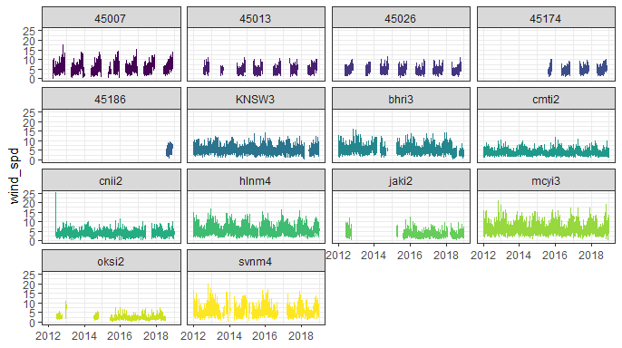

```r
p <- ggplot(data, aes(x = date, y = wind_spd, color = ordered(buoy_id), group = year))
p <- p + geom_line()
p <- p + facet_wrap(~ ordered(buoy_id), scales = "fixed")
p <- p + theme_bw() + theme(
  legend.position = "none"
) + xlab(NULL)
p
```

## Model Training with Nested CV

- We’ll simply and incorrectly set our grouping column, `buoy_id`, to numeric to work smoothly with `xgboost`. Better alternatives include [feature embedding](https://arxiv.org/abs/1604.06737), [target encoding](http://docs.h2o.ai/h2o/latest-stable/h2o-docs/data-munging/target-encoding.html) (available in the `R` package `catboost`), or [mixed effects Random Forests](https://arxiv.org/pdf/1901.11279.pdf).
- To be clear, `buoy_id` is both (a) used to identify a specific time series for creating lagged features and (b) used as a feature in the model.

```r
data$buoy_id <- as.numeric(factor(data$buoy_id))
```

### Training dataset - `forecastML::create_lagged_df`

- We have 3 datasets for training models that forecast 1, 1 to 7, and 1 to 30 days into the future. We’ll view the 1-day-ahead training data below.

```r
outcome_col <- 1  # The column position of our 'wind_spd' outcome (after removing the 'date' column).

horizons <- c(1, 7, 30)  # Forecast 1, 1:7, and 1:30 days into the future.

lookback <- c(1:30, 360:370)  # Features from 1 to 30 days in the past and annually.

dates <- data$date  # Grouped time series forecasting requires dates.
data$date <- NULL  # Dates, however, don't need to be in the input data.

frequency <- "1 day"  # A string that works in base::seq(..., by = "frequency").

dynamic_features <- c("day", "year")  # Features that change through time but which will not be lagged.

groups <- "buoy_id"  # 1 forecast for each group or buoy.

static_features <- c("lat", "lon")  # Features that do not change through time.
```

```r
type <- "train"  # Create a model-training dataset.

data_train <- forecastML::create_lagged_df(data, type = type, outcome_col = outcome_col,
                                           horizons = horizons, lookback = lookback,
                                           dates = dates, frequency = frequency,
                                           dynamic_features = dynamic_features,
                                           groups = groups, static_features = static_features,
                                           use_future = FALSE)

DT::datatable(head(data_train$horizon_1), options = list(scrollX = TRUE))
```

|  | wind_spd | buoy_id | wind_spd_lag_1 | wind_spd_lag_2 | wind_spd_lag_3 | wind_spd_lag_4 | wind_spd_lag_5 | wind_spd_lag_6 | wind_spd_lag_7 | wind_spd_lag_8 | wind_spd_lag_9 | wind_spd_lag_10 | wind_spd_lag_11 | wind_spd_lag_12 | wind_spd_lag_13 | wind_spd_lag_14 | wind_spd_lag_15 | wind_spd_lag_16 | wind_spd_lag_17 | wind_spd_lag_18 | wind_spd_lag_19 | wind_spd_lag_20 | wind_spd_lag_21 | wind_spd_lag_22 | wind_spd_lag_23 | wind_spd_lag_24 | wind_spd_lag_25 | wind_spd_lag_26 | wind_spd_lag_27 | … |
| --- | --- | --- | --- | --- | --- | --- | --- | --- | --- | --- | --- | --- | --- | --- | --- | --- | --- | --- | --- | --- | --- | --- | --- | --- | --- | --- | --- | --- | --- | --- |
| 1 | 2.53 | 1 |  |  |  |  |  |  |  |  |  |  |  |  |  |  |  |  |  |  |  |  |  |  |  |  |  |  |  | … |
| 2 | 0.18 | 1 | 2.53 |  |  |  |  |  |  |  |  |  |  |  |  |  |  |  |  |  |  |  |  |  |  |  |  |  |  | … |
| 3 | 1.13 | 1 | 0.18 | 2.53 |  |  |  |  |  |  |  |  |  |  |  |  |  |  |  |  |  |  |  |  |  |  |  |  |  | … |
| 4 | 6.65 | 1 | 1.13 | 0.18 | 2.53 |  |  |  |  |  |  |  |  |  |  |  |  |  |  |  |  |  |  |  |  |  |  |  |  | … |
| 5 | 8.91 | 1 | 6.65 | 1.13 | 0.18 | 2.53 |  |  |  |  |  |  |  |  |  |  |  |  |  |  |  |  |  |  |  |  |  |  |  | … |
| 6 | 5.58 | 1 | 8.91 | 6.65 | 1.13 | 0.18 | 2.53 |  |  |  |  |  |  |  |  |  |  |  |  |  |  |  |  |  |  |  |  |  |  | … |

- The plot below shows the feature map for any lagged features across forecast horizons. Here, we set all non-dynamic and non-static features to have the same lags (refer to the custom lags vignette to see how this could be modified). Notice that features that don’t support direct forecasting to the given horizon–e.g., lags of 1 to 29 days for the 30-day-horizon model–are silently dropped.

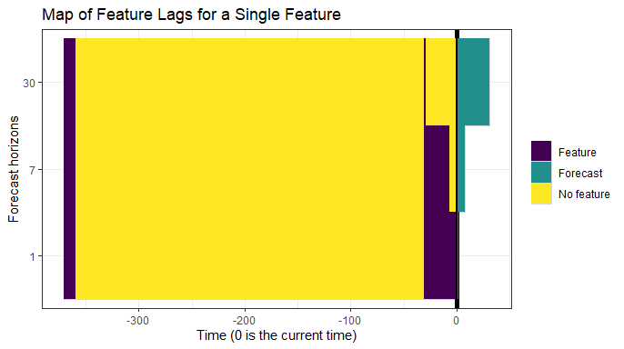

```r
p <- plot(data_train)  # plot.lagged_df() returns a ggplot object.
p <- p + geom_tile(NULL)  # Remove the gray border for a cleaner plot.
p
```

### CV setup - `forecastML::create_windows`

- We’ll model with **3 validation datasets**. Given that our measurements are taken daily, we’ll set the `skip = 730` argument to skip 2 years between validation datasets. Custom validation windows could be defined with vectors of start and stop dates given to `window_start` and `window_stop`.

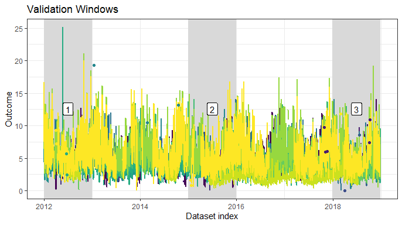

```r
windows <- forecastML::create_windows(data_train, window_length = 365, skip = 730,
                                      include_partial_window = FALSE)

p <- plot(windows, data_train) + theme(legend.position = "none")
p
```

- Now we’ll use the `group_filter = "buoy_id == 1"` argument to get a closer look at 1 of our 14 time series. The user-supplied filter is passed to `dplyr::filter()` internally.

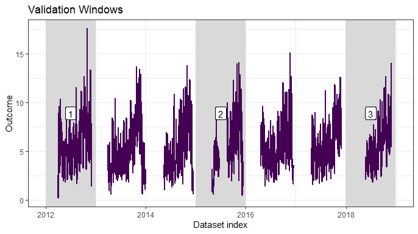

```r
p <- plot(windows, data_train, group_filter = "buoy_id == 1") +
  theme(legend.position = "none")
p
```

### User-defined modeling function

- A user-defined wrapper function for model training that takes the following arguments:
  - **1:** A horizon-specific data.frame made with `create_lagged_df(..., type = "train")` (e.g., my_lagged_df$horizon_h),
  - **2:** optionally, any number of additional named arguments which can be passed as ‘…’ in `train_model()`
  - and **returns** a model object or list containing a model that will be passed into the user-defined `predict()` function.

Any data transformations, hyperparameter tuning, or inner loop cross-validation procedures should take place within this function, with the limitation that it ultimately needs to `return()` a model suitable for the user-defined `predict()` function; a list can be returned to capture meta-data such as pre-processing pipelines or hyperparameter results.

- Notice that the `xgboost`-specific input datasets are created within this wrapper function.

```r
# The value of outcome_col can also be set in train_model() with train_model(outcome_col = 1).
model_function <- function(data, outcome_col = 1) {

  # xgboost cannot handle missing outcomes data.
  data <- data[!is.na(data[, outcome_col]), ]

  indices <- 1:nrow(data)

  set.seed(224)
  train_indices <- sample(1:nrow(data), ceiling(nrow(data) * .8), replace = FALSE)
  test_indices <- indices[!(indices %in% train_indices)]

  data_train <- xgboost::xgb.DMatrix(data = as.matrix(data[train_indices,
                                                           -(outcome_col), drop = FALSE]),
                                     label = as.matrix(data[train_indices,
                                                            outcome_col, drop = FALSE]))

  data_test <- xgboost::xgb.DMatrix(data = as.matrix(data[test_indices,
                                                          -(outcome_col), drop = FALSE]),
                                    label = as.matrix(data[test_indices,
                                                           outcome_col, drop = FALSE]))

  params <- list("objective" = "reg:linear")
  watchlist <- list(train = data_train, test = data_test)

  set.seed(224)
  model <- xgboost::xgb.train(data = data_train, params = params,
                              max.depth = 8, nthread = 2, nrounds = 30,
                              metrics = "rmse", verbose = 0,
                              early_stopping_rounds = 5,
                              watchlist = watchlist)

  return(model)
}
```

### Model training - `forecastML::train_model`

- This should take ~1 minute to train our ‘3 forecast horizons’ * ‘3 validation datasets’ = *9 models*.
- The user-defined modeling wrapper function could be much more elaborate, in which case many more models could potentially be trained here.
- These models could be trained in parallel on any OS with the very flexible `future` package by un-commenting the code below and setting `use_future = TRUE`. To avoid nested parallelization, models are either trained in parallel across forecast horizons or validation windows, whichever is longer (when equal, the default is parallel across forecast horizons).

```r
#future::plan(future::multiprocess)  # Multi-core or multi-session parallel training.

model_results_cv <- forecastML::train_model(lagged_df = data_train,
                                            windows = windows,
                                            model_name = "xgboost",
                                            model_function = model_function,
                                            use_future = FALSE)
```

- We can access the `xgboost` model for any horizon or validation window. Here, we show a `summary()` of the 1-step-ahead model for the first validation window which is 2012.

```r
summary(model_results_cv$horizon_1$window_1$model)
```

```
##                 Length Class              Mode
## handle               1 xgb.Booster.handle externalptr
## raw             333787 -none-             raw
## best_iteration       1 -none-             numeric
## best_ntreelimit      1 -none-             numeric
## best_score           1 -none-             numeric
## niter                1 -none-             numeric
## evaluation_log       3 data.table         list
## call                10 -none-             call
## params               5 -none-             list
## callbacks            2 -none-             list
## feature_names      128 -none-             character
## nfeatures            1 -none-             numeric
```

## Forecasting with Nested Models

- First, we’ll visually evaluate our model’s performance across our validation datasets.
- Then we’ll forecast with each of our 9 models to get a sense of the stability of the forecasts produced from models trained on different subsets of our historical data.

### User-defined prediction function

The following user-defined prediction function is needed for each model:

- A wrapper function that takes the following **2 positional arguments**:
  - **1:** The model returned from the user-defined modeling function (could be a list containing the model).
  - **2:** A `data.frame` of the model features from `forecastML::create_lagged_df(..., type = "train")`.
- and **returns** a `data.frame` of predictions with 1 or 3 columns. A 1-column data.frame will produce point forecasts, and a 3-column data.frame can be used to return point, lower, and upper forecasts (column names and order do not matter).

```r
# If 'model' is passed as a named list, the prediction model would be accessed with model$model or model["model"].
prediction_function <- function(model, data_features) {
  x <- xgboost::xgb.DMatrix(data = as.matrix(data_features))
  data_pred <- data.frame("y_pred" = predict(model, x),
                          "y_pred_lower" = predict(model, x) - 2,  # Optional; in practice, forecast bounds are not hard coded.
                          "y_pred_upper" = predict(model, x) + 2)  # Optional; in practice, forecast bounds are not hard coded.
  return(data_pred)
}
```

### Historical model fit

- Here, we’re predicting on our 3 validation datasets.

```r
data_pred_cv <- predict(model_results_cv, prediction_function = list(prediction_function), data = data_train)
```

- We’ll filter this plot for closer inspection below.

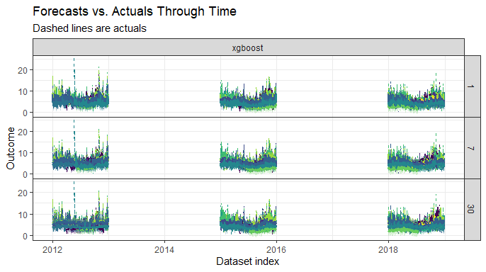

```r
plot(data_pred_cv) + theme(legend.position = "none")
```

- It’s somewhat difficult to see how we’ve done here, so we’ll use the `group_filter` and `facet` arguments to focus on specific buoys.

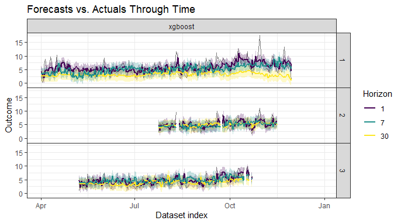

```r
plot(data_pred_cv, facet = group ~ model, group_filter = "buoy_id %in% c(1, 2, 3)", windows = 1)
```

- Here is another plot of the same historical predictions but with `facet = group ~ horizon`. Use different combinations of `model`, `horizon`, `group`, along with `.` (on the right hand side of `~`) in a formula with `~` to quickly explore results.

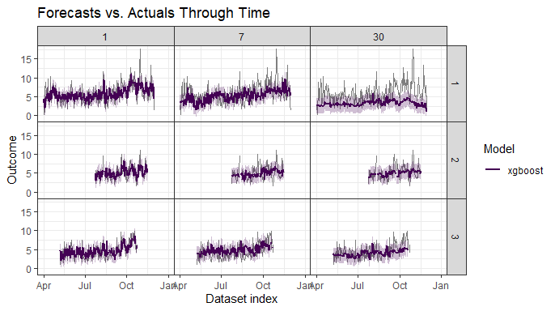

```r
plot(data_pred_cv, facet = group ~ horizon, group_filter = "buoy_id %in% c(1, 2, 3)", windows = 1)
```

### Historical prediction error - `forecastML::return_error`

- Let’s take a quick look at our historical forecast error for buoys 1:3.
- We’ll look at mean absolute error (a) for each validation window, (b) for each of the direct forecast horizons (collapsed across validation windows), and global error collapsed across validation windows and direct forecast horizons.

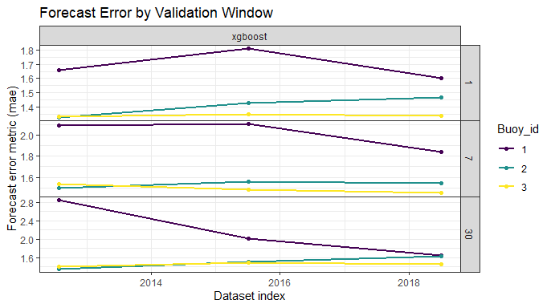

```r
data_error <- forecastML::return_error(data_pred_cv)

plot(data_error, type = "window", group_filter = "buoy_id %in% c(1, 2, 3)", metric = "mae")
```

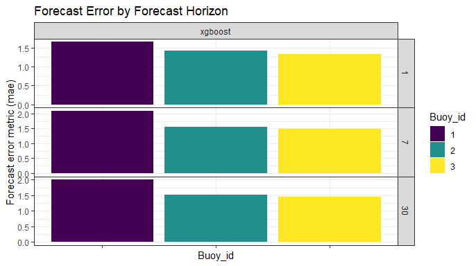

```r
plot(data_error, type = "horizon", group_filter = "buoy_id %in% c(1, 2, 3)", metric = "mae")
```

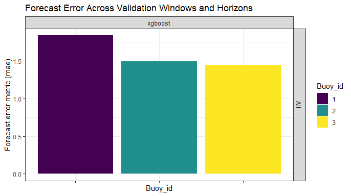

```r
plot(data_error, type = "global", group_filter = "buoy_id %in% c(1, 2, 3)", metric = "mae")
```

### Forecasting with multiple models from nested CV

- We have 3 datasets that support forecasting 1, 1 to 7, and 1 to 30 days into the future. We’ll view the 1-day-ahead forecasting data below.
- Note that the `index` and `horizon` columns are removed internally when passed into the user-defined `predict()` function.

```r
type <- "forecast"  # Create a forecasting dataset for our predict() function.

data_forecast <- forecastML::create_lagged_df(data, type = type, outcome_col = outcome_col,
                                              horizons = horizons, lookback = lookback,
                                              dates = dates, frequency = frequency,
                                              dynamic_features = dynamic_features,
                                              groups = groups, static_features = static_features,
                                              use_future = FALSE)

DT::datatable(head(data_forecast$horizon_1), options = list(scrollX = TRUE))
```

|  | index | horizon | buoy_id | wind_spd_lag_1 | wind_spd_lag_2 | wind_spd_lag_3 | wind_spd_lag_4 | wind_spd_lag_5 | wind_spd_lag_6 | wind_spd_lag_7 | wind_spd_lag_8 | wind_spd_lag_9 | wind_spd_lag_10 | wind_spd_lag_11 | wind_spd_lag_12 | wind_spd_lag_13 | wind_spd_lag_14 | wind_spd_lag_15 | wind_spd_lag_16 | wind_spd_lag_17 | wind_spd_lag_18 | wind_spd_lag_19 | wind_spd_lag_20 | wind_spd_lag_21 | wind_spd_lag_22 | wind_spd_lag_23 | wind_spd_lag_24 | wind_spd_lag_25 | wind_spd_lag_26 | … |
| --- | --- | --- | --- | --- | --- | --- | --- | --- | --- | --- | --- | --- | --- | --- | --- | --- | --- | --- | --- | --- | --- | --- | --- | --- | --- | --- | --- | --- | --- | --- |
| 1 | 2019-01-01 | 1 | 1 |  |  |  |  |  |  |  |  |  |  |  |  |  |  |  |  |  |  |  |  |  |  |  |  |  |  | … |
| 2 | 2019-01-01 | 1 | 2 |  |  |  |  |  |  |  |  |  |  |  |  |  |  |  |  |  |  |  |  |  |  |  |  |  |  | … |
| 3 | 2019-01-01 | 1 | 3 |  |  |  |  |  |  |  |  |  |  |  |  |  |  |  |  |  |  |  |  |  |  |  |  |  |  | … |
| 4 | 2019-01-01 | 1 | 4 |  |  |  |  |  |  |  |  |  |  |  |  |  |  |  |  |  |  |  |  |  |  |  |  |  |  | … |
| 5 | 2019-01-01 | 1 | 5 |  |  |  |  |  |  |  |  |  |  |  |  |  |  |  |  |  |  |  |  |  |  |  |  |  |  | … |
| 6 | 2019-01-01 | 1 | 6 | 4.57 | 5.44 | 4.17 | 7.02 | 9.57 | 2.23 | 1.74 | 4.89 | 3.85 | 3.13 | 7.73 | 4.2 | 4.52 | 3.27 | 4.55 | 3.39 | 3.75 | 2.67 | 3.45 | 7.42 | 4.32 | 3.19 | 3.2 | 2.74 | 4.17 | 5.47 | … |

### Dynamic features and forecasting

- Our dynamic features `day` and `year` were not lagged in our modeling dataset. This was the right choice from a modeling perspective; however, in order to forecast ‘h’ steps ahead, we need to know their future values for each forecast horizon. At present, there’s no function in `forecastML` to autofill the future values of dynamic, non-lagged features so we’ll simply do it manually below.

```r
for (i in seq_along(data_forecast)) {
  data_forecast[[i]]$day <- lubridate::mday(data_forecast[[i]]$index)  # When dates are given, the 'index` is date-based.
  data_forecast[[i]]$year <- lubridate::year(data_forecast[[i]]$index)
}
```

### Forecast

- Now we’ll forecast 1, 1:7, and 1:30 days into the future with `predict(..., data = data_forecast)`.
- The first time step into the future is `max(dates) + 1 * frequency`. Here, this is 12-31-2018 + 1 * ‘1 day’ or 1-1-2019.

```r
data_forecasts <- predict(model_results_cv, prediction_function = list(prediction_function), data = data_forecast)
```

- Plots for each model–just `xgboost` here–and direct forecast horizon. Because there are 3 `xgboost` models for each direct forecast horizon there are 3 points/lines for each buoy within each direct forecast horizon.

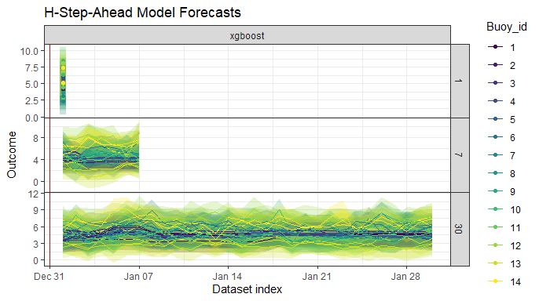

```r
plot(data_forecasts)
```

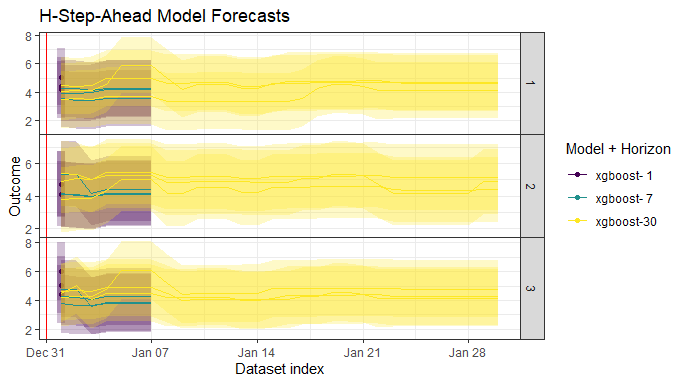

```r
plot(data_forecasts, facet = group ~ ., group_filter = "buoy_id %in% 1:3")
```

## Model Training with All Data

- The modeling steps are more or less the same as in the nested cross-validation modeling described above so we’ll skip the explanations from here on out.
- Notice that by this point in the modeling process, the optimal hyperparameters that gave the best performance on the outer-loop validation datasets have already been identified (see the package overview vignette). Incorporating the optimal hyperparameters in a final model would occur in a new user-defined modeling wrapper function.
- Train across all data by setting **`window_length = 0`**.

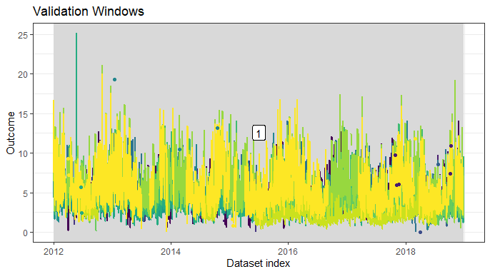

```r
windows <- forecastML::create_windows(data_train, window_length = 0)

p <- plot(windows, data_train) + theme(legend.position = "none")
p
```

```r
# Un-comment the code below and set 'use_future' to TRUE.
#future::plan(future::multiprocess)

model_results_no_cv <- forecastML::train_model(lagged_df = data_train,
                                               windows = windows,
                                               model_name = "xgboost",
                                               model_function = model_function,
                                               use_future = FALSE)
```

```r
data_forecasts <- predict(model_results_no_cv, prediction_function = list(prediction_function), data = data_forecast)

DT::datatable(head(data_forecasts), options = list(scrollX = TRUE))
```

|  | model | model_forecast_horizon | horizon | window_length | window_number | forecast_period | buoy_id | wind_spd_pred | wind_spd_pred_lower | wind_spd_pred_upper |
| --- | --- | --- | --- | --- | --- | --- | --- | --- | --- | --- |
| 1 | xgboost | 1 | 1 | 0 | 1 | 2019-01-01 | 1 | 5.08787822723389 | 3.08787822723389 | 7.08787822723389 |
| 2 | xgboost | 1 | 1 | 0 | 1 | 2019-01-01 | 2 | 4.70695018768311 | 2.70695018768311 | 6.70695018768311 |
| 3 | xgboost | 1 | 1 | 0 | 1 | 2019-01-01 | 3 | 5.08787822723389 | 3.08787822723389 | 7.08787822723389 |
| 4 | xgboost | 1 | 1 | 0 | 1 | 2019-01-01 | 4 | 6.23483276367188 | 4.23483276367188 | 8.23483276367188 |
| 5 | xgboost | 1 | 1 | 0 | 1 | 2019-01-01 | 5 | 7.20142269134521 | 5.20142269134521 | 9.20142269134521 |
| 6 | xgboost | 1 | 1 | 0 | 1 | 2019-01-01 | 6 | 5.21008253097534 | 3.21008253097534 | 7.21008253097534 |

## Forecast Combination - `forecastML::combine_forecasts`

- The **final step in the `forecastML` framework** is to combine multiple direct-horizon forecast models with `combine_forecasts()` to produce a single h-step-ahead forecast.
- The default approach, `type = 'horizon'`, is to combine forecasts across models such that short-term models produce the shorter-term forecasts and long-term models produce the longer-term forecasts. This implies that, for our 30-day-ahead forecast,
  - The 1-step-ahead model forecasts the next day,
  - The 7-step-ahead model forecasts from days 2 through 7, and
  - The 30-step-ahead model forecasts from days 8 through 30.

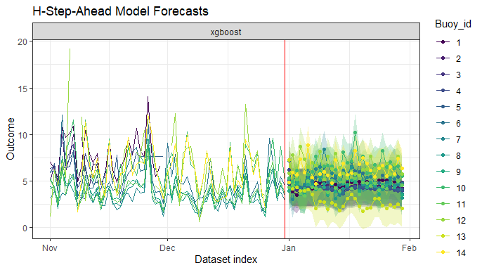

```r
data_combined <- forecastML::combine_forecasts(data_forecasts)

# Plot a background dataset of actuals using the most recent data.
data_actual <- data[dates >= as.Date("2018-11-01"), ]
actual_indices <- dates[dates >= as.Date("2018-11-01")]

# Plot all final forecasts plus historical data.
plot(data_combined, data_actual = data_actual, actual_indices = actual_indices)
```

- Below we’ll get a closer look at the actuals and forecasts by setting `facet = ~ group`. We’ll also filter to examine buoys 1, 11, and 12 because they have different historical patterns of missing data.

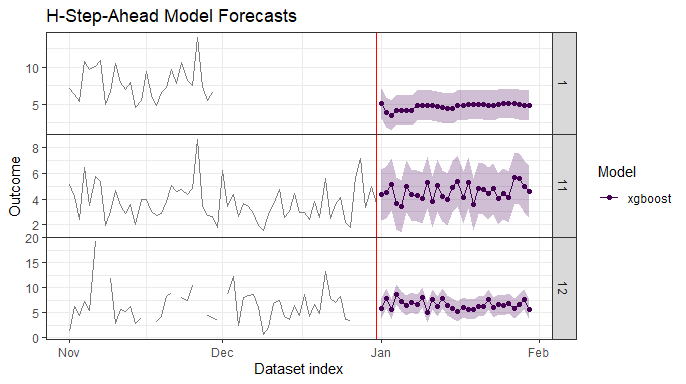

```r
plot(data_combined, data_actual = data_actual, actual_indices = actual_indices,
     facet = group ~ ., group_filter = "buoy_id %in% c(1, 11, 12)")
```

- Plot a single forecast.

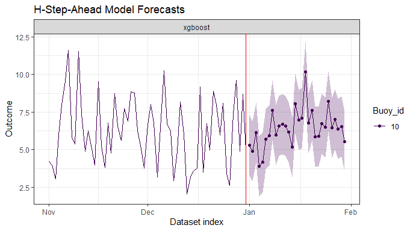

```r
# Plot final forecasts for a single buoy plus historical data.
plot(data_combined, data_actual = data_actual, actual_indices = actual_indices,
     group_filter = "buoy_id == 10")
```